# Importing Libraries

```python
#importing necessary libraries

import numpy as np
import pandas as pd
import matplotlib.pyplot as plt
%matplotlib inline

import seaborn as sns
from scipy import stats

from scipy.stats import pearsonr
from sklearn import metrics
from sklearn.decomposition import PCA

from sklearn.preprocessing import StandardScaler, RobustScaler, MinMaxScaler
from sklearn.model_selection import train_test_split
from sklearn.neighbors import KNeighborsClassifier
from sklearn.metrics import accuracy_score, roc_curve, auc, classification_report, recall_score, precision_score, f1_score
from sklearn.model_selection import cross_val_score


import pandas_profiling
from xgboost import XGBClassifier

import warnings
warnings.filterwarnings("ignore")
```

```python
pd.set_option('display.float_format', lambda x: '%.5f' % x)
```

# EDA

Renaming columns

```python
df = pd.read_csv('ratings_Electronics.csv')
cols = ['userID','productID', 'ratings', 'timestamp']
df.columns = cols
```

```python
df.shape
```

```
(7824481, 4)
```

The dataset has 7824481 rows and 4 columns

```python
df.drop("timestamp",axis=1, inplace=True) #timestamp is irrelevant
df.head()
```

|  | userID | productID | ratings |
| --- | --- | --- | --- |
| 0 | A2CX7LUOHB2NDG | 0321732944 | 5.00000 |
| 1 | A2NWSAGRHCP8N5 | 0439886341 | 1.00000 |
| 2 | A2WNBOD3WNDNKT | 0439886341 | 3.00000 |
| 3 | A1GI0U4ZRJA8WN | 0439886341 | 1.00000 |
| 4 | A1QGNMC6O1VW39 | 0511189877 | 5.00000 |

```python
print(f"Total number of unique users: {df['userID'].nunique()}")
print(f"Total number of unique products: {df['productID'].nunique()}")
```

```
Total number of unique users: 4201696
Total number of unique products: 476001
```

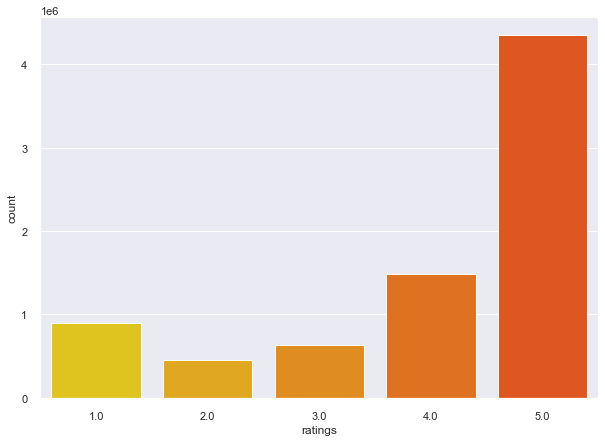

```python
plt.figure(figsize=(10,7))
sns.set_context('notebook')
sns.set_palette('autumn_r')
sns.countplot(df['ratings'])
```

Most of the people have submitted a 5 star rating, with 2 stars being the least frequent.

```python
product_rating = df.groupby('productID')['ratings'].mean()
```

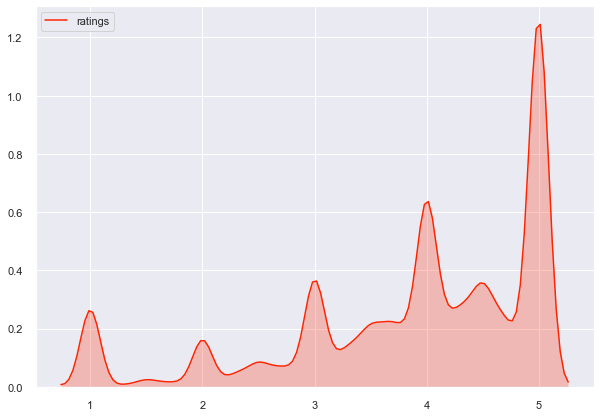

```python
plt.figure(figsize=(10,7))
sns.set_context('notebook')
sns.set_palette('autumn')
sns.kdeplot(product_rating, shade=True)
```

```python
pd.DataFrame(df.groupby("userID")['ratings'].count().sort_values(ascending=False)).head(15)
```

| userID | ratings |
| --- | --- |
| A5JLAU2ARJ0BO | 520 |
| ADLVFFE4VBT8 | 501 |
| A3OXHLG6DIBRW8 | 498 |
| A6FIAB28IS79 | 431 |
| A680RUE1FDO8B | 406 |
| A1ODOGXEYECQQ8 | 380 |
| A36K2N527TXXJN | 314 |
| A2AY4YUOX2N1BQ | 311 |
| AWPODHOB4GFWL | 308 |
| A25C2M3QF9G7OQ | 296 |
| ARBKYIVNYWK3C | 296 |
| A22CW0ZHY3NJH8 | 292 |
| A3EXWV8FNSSFL6 | 282 |
| A38RMU1Y5TDP9 | 282 |
| A3LGT6UZL99IW1 | 279 |

These are users with the maximum number of reviews.

```python
df.describe()
```

|  | ratings |
| --- | --- |
| count | 7824481.00000 |
| mean | 4.01234 |
| std | 1.38091 |
| min | 1.00000 |
| 25% | 3.00000 |
| 50% | 5.00000 |
| 75% | 5.00000 |
| max | 5.00000 |

# Creating a subset of the dataset

Sorting users by the number of reviews they have:

```python
user_rating_df = df.groupby('userID')['ratings'].agg(['mean','count'])
user_rating_df.sort_values(by=['count','mean'],ascending=False).head()
```

| userID | mean | count |
| --- | --- | --- |
| A5JLAU2ARJ0BO | 3.86154 | 520 |
| ADLVFFE4VBT8 | 4.28343 | 501 |
| A3OXHLG6DIBRW8 | 4.45181 | 498 |
| A6FIAB28IS79 | 4.18329 | 431 |
| A680RUE1FDO8B | 4.40640 | 406 |

```python
user_rating_df.shape
```

```
(4201696, 2)
```

```python
rev_count = df.userID.value_counts()
```

Selecting reviewers with more than 50 reviews:

```python
df_user_rating=df[df['userID'].isin(rev_count[rev_count>=50].index)]
```

```python
df_user_rating.head()
```

|  | userID | productID | ratings |
| --- | --- | --- | --- |
| 93 | A3BY5KCNQZXV5U | 0594451647 | 5.00000 |
| 117 | AT09WGFUM934H | 0594481813 | 3.00000 |
| 176 | A32HSNCNPRUMTR | 0970407998 | 1.00000 |
| 177 | A17HMM1M7T9PJ1 | 0970407998 | 4.00000 |
| 491 | A3CLWR1UUZT6TG | 0972683275 | 5.00000 |

Shape of our final DF

```python
df_user_rating.shape
```

```
(125871, 3)
```

```python
print(f"Number of users with more than 50 reviews: {df_user_rating['userID'].nunique()}")
```

```
Number of users with more than 50 reviews: 1540
```

```python
df_user_rating.nunique()
```

```
userID        1540
productID    48190
ratings          5
dtype: int64
```

There are 1540 unique users, 48190 unique products with ratings from 1-5

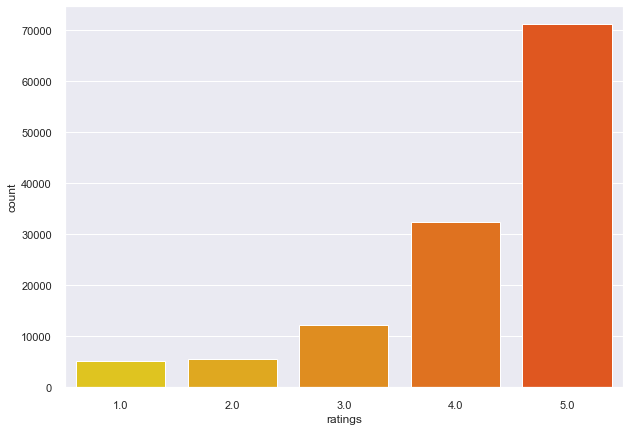

```python
plt.figure(figsize=(10,7))
sns.set_context('notebook')
sns.set_palette('autumn_r')
sns.countplot(df_user_rating['ratings'])
```

Maximum users from the pool of users filtered have given a rating of 5

```python
df_user_rating.ratings.value_counts()
```

```
5.00000    71034
4.00000    32295
3.00000    12060
2.00000     5367
1.00000     5115
Name: ratings, dtype: int64
```

# Popularity Based

It is a type of recommendation system which works on the principle of popularity and or anything which is in trend. These systems check about the product or movie which are in trend or are most popular among the users and directly recommend those.

For example, if a product is often purchased by most people then the system will get to know that that product is most popular so for every new user who just signed it, the system will recommend that product to that user also and chances becomes high that the new user will also purchase that.

We will sort popularity of products based on whether they have been rated by the top users or not.

```python
df_user_rating.head()
```

|  | userID | productID | ratings |
| --- | --- | --- | --- |
| 93 | A3BY5KCNQZXV5U | 0594451647 | 5.00000 |
| 117 | AT09WGFUM934H | 0594481813 | 3.00000 |
| 176 | A32HSNCNPRUMTR | 0970407998 | 1.00000 |
| 177 | A17HMM1M7T9PJ1 | 0970407998 | 4.00000 |
| 491 | A3CLWR1UUZT6TG | 0972683275 | 5.00000 |

```python
df_user_rating.groupby('productID')['ratings'].mean().sort_values(ascending=False).head()
```

```
productID
B00LKG1MC8   5.00000
B002QUZM3M   5.00000
B002QWNZHU   5.00000
B002QXZPFE   5.00000
B002R0DWNS   5.00000
Name: ratings, dtype: float64
```

```python
df_user_rating.groupby('productID')['ratings'].count().sort_values(ascending=False).head()
```

```
productID
B0088CJT4U    206
B003ES5ZUU    184
B000N99BBC    167
B007WTAJTO    164
B00829TIEK    149
Name: ratings, dtype: int64
```

```python
ratings_mean_count = pd.DataFrame(df_user_rating.groupby('productID')['ratings'].mean())
```

```python
ratings_mean_count['rating_counts'] = pd.DataFrame(df_user_rating.groupby('productID')['ratings'].count())
```

```python
ratings_mean_count.head()
```

| productID | ratings | rating_counts |
| --- | --- | --- |
| 0594451647 | 5.00000 | 1 |
| 0594481813 | 3.00000 | 1 |
| 0970407998 | 2.50000 | 2 |
| 0972683275 | 4.75000 | 4 |
| 1400501466 | 3.33333 | 6 |

Since popularity based systems are not personalized, the system would recommend the same sort of products/movies which are solely based upon popularity to every other user. There is no personalisation based on user and every user would be recommended the same sort of products.

Now out of all products rated the most, we only recommend the ones which have been rated for more than 100 times so that there is no bias or a case of a product being popular because of one 5 star rating.

```python
df_subset = ratings_mean_count[ratings_mean_count['rating_counts']>100]
```

```python
pd.DataFrame(df_subset.groupby('productID')['ratings'].mean().sort_values(ascending=False).head())
```

| productID | ratings |
| --- | --- |
| B003ES5ZUU | 4.86413 |
| B000N99BBC | 4.77246 |
| B007WTAJTO | 4.70122 |
| B002V88HFE | 4.69811 |
| B004CLYEDC | 4.66949 |

These are the products which have been rated at least 100 times and are the most popular ones with their average rating shown above.

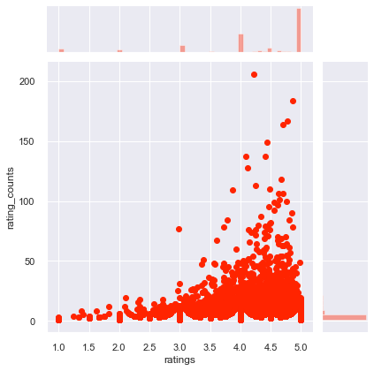

```python
sns.set_palette("autumn")
sns.set_style('darkgrid')
sns.jointplot(x='ratings', y='rating_counts', data=ratings_mean_count)
```

This shows the average rating over the number of ratings for all the products.

```python
df_user_rating.head()
#final dataframe
```

|  | userID | productID | ratings |
| --- | --- | --- | --- |
| 93 | A3BY5KCNQZXV5U | 0594451647 | 5.00000 |
| 117 | AT09WGFUM934H | 0594481813 | 3.00000 |
| 176 | A32HSNCNPRUMTR | 0970407998 | 1.00000 |
| 177 | A17HMM1M7T9PJ1 | 0970407998 | 4.00000 |
| 491 | A3CLWR1UUZT6TG | 0972683275 | 5.00000 |

# Collaborative Filtering : SVD

To address some of the limitations of content-based filtering, **collaborative filtering** uses similarities between users and items simultaneously to provide recommendations. This allows for serendipitous recommendations; that is, collaborative filtering models can recommend an item to user A based on the interests of a similar user B. Furthermore, the embeddings can be learned automatically, without relying on hand-engineering of features.

We make use of the Surprise library for Collaborative Filtering and the algorithms we will be using are SVD and KNN with Means.

```python
from surprise import SVD
from surprise import Dataset
from surprise.model_selection import cross_validate
from surprise import KNNWithMeans
from surprise import Dataset
from surprise import accuracy
from surprise.model_selection import train_test_split
from surprise import Reader
from collections import defaultdict
```

## Spliting data 70:30

```python
reader = Reader(rating_scale=(1, 5))
data = Dataset.load_from_df(df_user_rating, reader)
```

```python
trainset, testset = train_test_split(data, test_size=.30, random_state=42)
```

## fit algo on trainset (untuned)

```python
algo = SVD()
algo.fit(trainset)
```

```
<surprise.prediction_algorithms.matrix_factorization.SVD at 0x7ffbc9ab36a0>
```

## get predictions on testset

```python
predictions = algo.test(testset)
```

```python
predictions
```

[output not shown]

[output cut: 946 more lines]

[output not shown]

Prediction of ratings for each product by each user. We use thiss value to calculate RMSE, our choice of metric for this project.

## Untuned SVD RMSE score

```python
print("Untuned SVD Model : Test Set")
accuracy.rmse(predictions, verbose=True)
```

```
Untuned SVD Model : Test Set
RMSE: 0.9910
```

```
0.9909567889953871
```

## SVD Tuning : GridSearchCV

```python
from surprise.model_selection import GridSearchCV

param_grid = {'n_epochs': [5, 10], 'lr_all': [0.002, 0.005],
              'reg_all': [0.4, 0.6]}
gs = GridSearchCV(SVD, param_grid, measures=['rmse', 'mae'], cv=3)
gs.fit(data)
```

```python
print(f"Best score: {gs.best_score['rmse']}")
print(f"Best score: {gs.best_params['rmse']}")
```

```
Best score: 0.989277030446487
Best score: {'n_epochs': 10, 'lr_all': 0.005, 'reg_all': 0.4}
```

## Tuned SVD Score

```python
tuned_algo = SVD(n_epochs= 10, lr_all= 0.005, reg_all= 0.4)
tuned_algo.fit(trainset)
```

```
<surprise.prediction_algorithms.matrix_factorization.SVD at 0x7ffbc9d43438>
```

```python
predictions = tuned_algo.test(testset)
print("Tuned SVD Model : Test Set")
accuracy.rmse(predictions, verbose=True)
```

```
Tuned SVD Model : Test Set
RMSE: 0.9926
```

```
0.9926232101100544
```

The split that we did above was a 70:30 split where the test set contains products that the user has rated and hence, purchased. Our goal is to recomment products that have no been purchased by the user.  
For that purpose, we will define our dataset again with the train set containing values of products which have been rated by users and the test set being an anti-train set containing all zero values.

## Get top K recommendations : SVD (tuned)

### Recreating training data from scratch with only values which are present in our matrix.

```python
df_user_rating_sample = df_user_rating.sample(frac=0.1)
```

```python
print(df_user_rating.shape)
print(df_user_rating_sample.shape) #10% of original data for faster computation
```

```
(125871, 3)
(12587, 3)
```

```python
data_small = Dataset.load_from_df(df_user_rating_sample, reader)
```

```python
trainset_small = data_small.build_full_trainset()
tuned_algo = SVD(n_epochs= 10, lr_all= 0.005, reg_all= 0.4)
testset_small = trainset_small.build_anti_testset()
```

```python
tuned_algo.fit(trainset_small)
predictions = tuned_algo.test(testset_small)
```

```python
predictions
```

[output not shown]

[output cut: 946 more lines]

[output not shown]

```python
def get_top_n(predictions, n=5):
    # First map the predictions to each user.
    top_n = defaultdict(list)
    for uid, iid, true_r, est, _ in predictions:
        top_n[uid].append((iid, est))

    # Then sort the predictions for each user and retrieve the k highest ones.
    for uid, user_ratings in top_n.items():
        user_ratings.sort(key=lambda x: x[1], reverse=True)
        top_n[uid] = user_ratings[:n]

    return top_n
```

```python
top_n = get_top_n(predictions, n=5)
```

Take a sample user:

```python
user = str('A3BY5KCNQZXV5U')
for uid, user_ratings in top_n.items():
    if uid == user:
        print(f"Top 5 new products for user {user}:")
        for (iid, _) in user_ratings:
            print(iid)
```

```
Top 5 new products for user A3BY5KCNQZXV5U:
B001CBFTFM
B002VPE1Q6
B00D68Y9B4
B0026FCI2U
B008HK3WK0
```

Another user:

```python
user = str('A2QAOP52OEB5EV')
for uid, user_ratings in top_n.items():
    if uid == user:
        print(f"Top 5 new products for user {user}:")
        for (iid, _) in user_ratings:
            print(iid)
```

```
Top 5 new products for user A2QAOP52OEB5EV:
B000066HUC
B0099SMFVQ
B001TH7GUU
B001HOYZV8
B002K9IHGI
```

Another user:

```python
user = str('A17HMM1M7T9PJ1')
for uid, user_ratings in top_n.items():
    if uid == user:
        print(f"Top 5 new products for user {user}:")
        for (iid, _) in user_ratings:
            print(iid)
```

```
Top 5 new products for user A17HMM1M7T9PJ1:
B000N99BBC
B002L60TTI
B00BJ6XZEM
B00B99JU5M
B005CT56F8
```

# Collaborative Filtering: kNN with Means

## User-User

### Fitting on trainset

```python
knn = KNNWithMeans(k=50, sim_options={'name': 'pearson_baseline', 'user_based': True})
knn.fit(trainset)
```

```
Estimating biases using als...
Computing the pearson_baseline similarity matrix...
Done computing similarity matrix.
```

```
<surprise.prediction_algorithms.knns.KNNWithMeans at 0x7ffc05f0ec88>
```

### Predicting on testset

```python
test_pred_knn = knn.test(testset)
accuracy.rmse(test_pred_knn, verbose=True)
```

```
RMSE: 1.0618
```

```
1.0618108041248628
```

### Predicting rating by one user for one product

```python
uid = str('A3CLWR1UUZT6TG')
iid = str('0594451647')
pred = knn.predict(uid,iid, verbose=True)
```

```
user: A3CLWR1UUZT6TG item: 0594451647 r_ui = None   est = 4.41   {'actual_k': 0, 'was_impossible': False}
```

## Item-item

### Fitting on trainset

```python
knn_ii = KNNWithMeans(k=50, sim_options={'name': 'pearson_baseline', 'user_based': False})
knn_ii.fit(trainset)
```

```
Estimating biases using als...
Computing the pearson_baseline similarity matrix...
Done computing similarity matrix.
```

```
<surprise.prediction_algorithms.knns.KNNWithMeans at 0x7ffbcf9133c8>
```

### Predicting on testset

```python
test_pred_knn = knn_ii.test(testset)
accuracy.rmse(test_pred_knn, verbose=True)
```

```
RMSE: 1.1381
```

```
1.138130737437999
```

The split that we did above was a 70:30 split where the test set contains products that the user has rated and hence, purchased. Our goal is to recomment products that have no been purchased by the user.  
For that purpose, we will define our dataset again with the train set containing values of products which have been rated by users and the test set being an anti-train set containing all zero values.

## Predicting using small datasets

The small train and set sets we used are train and anti train sets where train set has values rated by users and test set has blank values for unseen products.

```python
knn.fit(trainset_small) #using user-user knn with means
knn_predictions = knn.test(testset_small)
```

```
Estimating biases using als...
Computing the pearson_baseline similarity matrix...
Done computing similarity matrix.
```

```python
knn_predictions
```

[output not shown]

[output cut: 946 more lines]

[output not shown]

```python
def get_top_n(predictions, n=5):
    # First map the predictions to each user.
    top_n = defaultdict(list)
    for uid, iid, true_r, est, _ in predictions:
        top_n[uid].append((iid, est))

    # Then sort the predictions for each user and retrieve the k highest ones.
    for uid, user_ratings in top_n.items():
        user_ratings.sort(key=lambda x: x[1], reverse=True)
        top_n[uid] = user_ratings[:n]

    return top_n
```

```python
top_n = get_top_n(predictions, n=5)
```

Taking a sample user:

```python
user = str('A3CLWR1UUZT6TG')
for uid, user_ratings in top_n.items():
    if uid == user:
        print(f"Top 5 new products for user {user}:")
        for (iid, _) in user_ratings:
            print(iid)
```

```
Top 5 new products for user A3CLWR1UUZT6TG:
B0095ABFGO
B000G25N2M
B005GOINEK
B007WTAJTO
B00HXE4H1E
```

Another user:

```python
user = str('A2QAOP52OEB5EV')
for uid, user_ratings in top_n.items():
    if uid == user:
        print(f"Top 5 new products for user {user}:")
        for (iid, _) in user_ratings:
            print(iid)
```

```
Top 5 new products for user A2QAOP52OEB5EV:
B000066HUC
B0099SMFVQ
B001TH7GUU
B001HOYZV8
B002K9IHGI
```

Another user:

```python
user = str('A17HMM1M7T9PJ1')
for uid, user_ratings in top_n.items():
    if uid == user:
        print(f"Top 5 new products for user {user}:")
        for (iid, _) in user_ratings:
            print(iid)
```

```
Top 5 new products for user A17HMM1M7T9PJ1:
B000N99BBC
B002L60TTI
B00BJ6XZEM
B00B99JU5M
B005CT56F8
```

# Insights:

Both the algorithms, Single Value Decomposition and KNNwithMeans fared well for our recommendations.

There is no way of measuring the performance of popularity based recommendations so we have to take a guess at the threshold of minimum ratings and display the most rated products.

In collaborative filtering, we make use of SVD which is essentially a User-Item filter as well as User-user and item-item using KNN means

First we split the dataset into train and test set of 70:30 for both the algorithms. We then used the Surprise library for fitting the algorithms on train set and predicting on test set. Based on the predicted values, we evaluated our model based on RMSE values.

We make use of GridSearchCV to optimize the SVD algorithm.

After having evaluated each model, we make use of another approach to show predictions. We split the whole(users with 50+ ratings only) into two parts,  
train set: consisting of only ratings that has been provided by users, &  
testset: which is the anti-train set consisting of all empty rating values.

We made use of this approach so that only products which have not been rated/purchased by users will be recommended to them based on their habits/habits of similar users. This ensured that no product which was rated high by the user shows up in the recommendations.

Since SVD had the lowest RMSE(0.99), we use that out of the two collaborative filtering models we had built to recommend products to our users.